# k-Means Clustering

In this notebook, you will implement the k-means clustering algorithm.

## Packages

Following packages is all you need. Do not import any additional packages!

In case you are not familiar with [Numpy](http://www.numpy.org/) library, it provides support for large multi-dimensional arrays and matrices, along with functions to operate on these. [Matplotlib](https://matplotlib.org/) is a plotting library.

```python
import numpy as np
import math
%matplotlib inline
from matplotlib import pyplot as plt
```

## Function

A function for plotting that we are going to use later on.

```python
def plot_clusters(data, centroids):
    """
    Shows a scatter plot with the data points clustered according to the centroids.
    """
    # Assigning the data points to clusters/centroids.
    clusters = [[] for _ in range(centroids.shape[0])]
    for i in range(data.shape[0]):
        distances = np.linalg.norm(data[i] - centroids, axis=1)
        clusters[np.argmin(distances)].append(data[i])

    # Plotting clusters and centroids.
    fig, ax = plt.subplots()
    for c in range(centroids.shape[0]):
        if len(clusters[c]) > 0:
            cluster = np.array(clusters[c])
            ax.scatter(cluster[:, 0], cluster[:, 1], s=7)
    ax.scatter(centroids[:, 0], centroids[:, 1], marker='x', s=200, c='red')
```

## Data

Let us generate a dataset you are going to play with. We will stay in the Euclidean space because it is easy to plot.

```python
# We would like to have some control over the randomly generated data.
# This is just for development purposes.
np.random.seed(0)

# Euclidean space.
DIMENSIONS = 2

# We will generate clusters.
CLUSTERS = [
    {
        'mean': (50, 50),
        'std': (5, 10),
        'size': 300
    },
    {
        'mean': (10, 85),
        'std': (10, 3),
        'size': 100
    },
    {
        'mean': (10, 10),
        'std': (6, 6),
        'size': 200
    },
    {
        'mean': (10, 75),
        'std': (10, 5),
        'size': 200
    },
    {
        'mean': (80, 20),
        'std': (5, 5),
        'size': 100
    }
]

# Initializing the dataset with zeros.
synthetic_data = np.zeros((np.sum([c['size'] for c in CLUSTERS]), DIMENSIONS))

# Generating the clusters.
start = 0
for c in CLUSTERS:
    for d in range(DIMENSIONS):
        synthetic_data[start:start + c['size'], d] = np.random.normal(c['mean'][d], c['std'][d], (c['size']))
    start += c['size']
print(synthetic_data)
```

```
[[58.82026173 36.93473148]
 [52.00078604 66.5813068 ]
 [54.89368992 48.81835955]
 ...
 [80.85621773 20.91725127]
 [80.19454353 17.64628751]
 [83.13282125 21.36398195]]
```

```python
print('shape (size, dimensions) =', synthetic_data.shape)
```

```
shape (size, dimensions) = (900, 2)
```

And this is how our data look like when plotted.

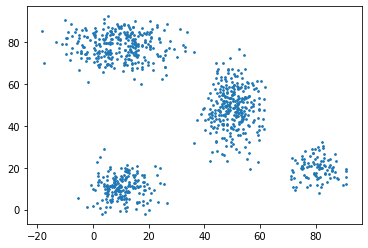

```python
plt.figure()
plt.scatter(synthetic_data[:, 0], synthetic_data[:, 1], s=3)
```

## Implementation

A human can with an ease find four distinct clusters just by watching the plot. A computer, however, needs to be told how to find the clusters.

**Exercise:**

Implement the k-means clustering algorithm.

- Use the Euclidean (L<sub>2</sub>) distance.
- It is sufficient to use the basic Python constructs in your implementation, even though we heavily rely on Numpy throughout this assignment.

```python
def kmeans(data, centroids):
    ### START CODE HERE ###

    rows = len(data)
    columns = len(centroids)
    hash_map_x = {}# I will hold the sum of the coordinates for each cluster here
    hash_map_y = {}# example: {"0": 1325.315, "1": 151.315}
    stop_condition = np.empty((0, 2), float)
    counter = 0 # necessary for the finish line
    centroids = centroids.astype(float) # for better precision
    data = data.astype(float) # for better precision
    cluster_count_x_map = {}# I will hold the number of points each cluster has in order to divid the hash_map_x
    cluster_count_y_map = {}# same for y

    for i in range(len(data)):  # data is an array containing every point's location which is also an array
        # i is a [x,y] item right now
        distance_array = np.empty(columns,dtype=float)  # define the array that will contain the distance of the point from every centroid
        for k in range(len(centroids)):
            distance = np.linalg.norm(data[i] - centroids[k])
            distance_array = np.insert(distance_array, k, distance)  # adding it to the array
            distance_array = np.delete(distance_array, k + 1)  # delete the dummy values
        # nested loop is done, we claim the shorter distance
        min_distance = np.amin(distance_array)  # which distance was the minimum?
        cluster = np.where(distance_array == min_distance)[0][0]  # which cluster claims the point?

        if cluster not in hash_map_x: # if this is the first datapoint for this cluster
            hash_map_x[cluster] = data[i][0] # add the cluster to the hashmap along with the point
            cluster_count_x_map[cluster] = 1 # add the point to the hash map to calculate the mean later
        else: # if not
            old_values_x = hash_map_x.get(cluster) # get the old value
            new_value_x = (old_values_x + data[i][0])# add all the coordinates and store them in the map
            hash_map_x[cluster] = new_value_x
            cluster_count_x_map[cluster]+=1


        if cluster not in hash_map_y: # same for the y axis
            hash_map_y[cluster] = data[i][1]
            cluster_count_y_map[cluster] = 1
        else:
            old_values_y = hash_map_y.get(cluster)
            new_value_y = (old_values_y + data[i][1])
            hash_map_y[cluster] = new_value_y
            cluster_count_y_map[cluster]+=1

    for k in range(len(centroids)):
        x_sum = hash_map_x.get(k)
        x_data = cluster_count_x_map.get(k)
        x_mean = x_sum/x_data # using the 2 x hash maps I calculate the mean
        y_sum = hash_map_y.get(k)
        y_data = cluster_count_y_map.get(k)
        y_mean = y_sum/y_data # using the 2 y hash maps I calculate the mean
        stop_condition = np.insert(stop_condition, k, np.array([[x_mean, y_mean]]), axis=0) # add them here to compare
        difference = np.linalg.norm(stop_condition[k] - centroids[k]) # how big is the shift?
        if difference < 0.001:
            counter = counter + 1 # the counter has to be equal to k because we want all the clusters to have low shift

        centroids = np.insert(centroids, k, np.array([[x_mean, y_mean]]), axis=0) # update the centroids
        centroids = np.delete(centroids, k+1, axis=0)
    if counter == len(centroids):  # if the counter = k stop and return the centroids
        return centroids
    else:
        return kmeans(data, centroids) # recursion
    ### END CODE HERE ###
```

We have prepared for you a small piece of code, so that you can test that the function works according the expectations.

```
c0 = [10.60838779 23.74997384]
c1 = [49.02859109 49.15205809]
c2 = [76.15408829 21.7746025 ]
```

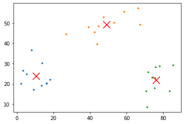

```python
test_data = np.array([
    [66.24345364, 57.31053969],
    [43.88243586, 39.69929645],
    [44.71828248, 48.38791398],
    [39.27031378, 48.07972823],
    [58.65407629, 55.66884721],
    [26.98461303, 44.50054366],
    [67.44811764, 49.13785896],
    [42.38793099, 45.61070791],
    [53.19039096, 50.21106873],
    [47.50629625, 52.91407607],
    [2.29566576, 20.15837474],
    [18.01306597, 22.22272531],
    [16.31113504, 20.1897911 ],
    [13.51746037, 19.08356051],
    [16.30599164, 20.30127708],
    [5.21390499, 24.91134781],
    [9.13976842, 17.17882756],
    [3.44961396, 26.64090988],
    [8.12478344, 36.61861524],
    [13.71248827, 30.19430912],
    [74.04082224, 23.0017032 ],
    [70.56185518, 16.47750154],
    [71.26420853, 8.57481802],
    [83.46227301, 16.50657278],
    [75.25403877, 17.91105767],
    [71.81502177, 25.86623191],
    [75.95457742, 28.38983414],
    [85.50127568, 29.31102081],
    [75.60079476, 22.85587325],
    [78.08601555, 28.85141164]
])
test_centroids = np.array([
    [25, 50],
    [50, 50],
    [75, 50]
])
test_centroids = kmeans(test_data, test_centroids)

print('c0 =', test_centroids[0])
print('c1 =', test_centroids[1])
print('c2 =', test_centroids[2])
plot_clusters(test_data, test_centroids)
```

We expect the output to be similar to following.

```
c0 = [ 9 25]
c1 = [50 50]
c2 = [75 20]
```

If it is not the case, review your implementation, debug your algorithm, try it on paper, ...

## Clustering

Ready to run your implementation of k-means clustering on the dataset? Let's do it...

First, we need to initialize the centroids. We will go for a random initialization eventhough there are some disadvantages of doing so (see the Introduction to Data Mining from Tan et al.).

```
c0 = [32.  1.]
c1 = [75.  6.]
c2 = [65. 88.]
c3 = [16. 80.]
```

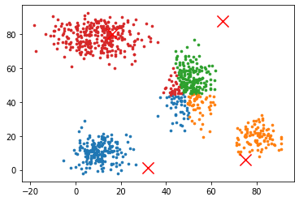

```python
# Number of clusters.
K = 4

# Boundaries of our data.
x_min = np.min(synthetic_data[:, 0])
x_max = np.max(synthetic_data[:, 0])
y_min = np.min(synthetic_data[:, 1])
y_max = np.max(synthetic_data[:, 1])

# Generating random centroids within the data boundaries.
centroids = np.zeros((K, synthetic_data.shape[1]))
centroids[:, 0] = np.random.randint(x_min, x_max, size=K)
centroids[:, 1] = np.random.randint(y_min, y_max, size=K)

for i in range(len(centroids)):
    print('c%d =' % i, centroids[i])
plot_clusters(synthetic_data, centroids)
```

Finally, we run the `kmeans()` function you have implemented.

```
c0 = [10.40705505 10.57646643]
c1 = [79.6476723  19.74229223]
c2 = [50.06781387 48.89278837]
c3 = [ 9.55339231 78.22785577]
```

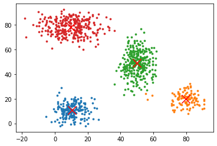

```python
centroids = kmeans(synthetic_data, centroids)

# plt.scatter(data[:, 0], data[:, 1], s=3)
# plt.scatter(centroids[:, 0], centroids[:, 1], marker='x', s=200, c='red')

for i in range(len(centroids)):
    print('c%d =' % i, centroids[i])
plot_clusters(synthetic_data, centroids)
```

Congratulations! At this point, hopefully, you have found all four distinct clusters with the centroids aligned in their centers.

## Evaluation of Clustering

Silhouette Coefficient is an example of a measure for validation of the cluster quality.

**Exercise:**

Implement a function calculating the mean Silhouette Coefficient of all samples.

- Use the Euclidean (L<sub>2</sub>) distance.
- It is sufficient to use the basic Python constructs in your implementation, even though we heavily rely on Numpy throughout this assignment.

```python
def silhouette_score(data, centroids):

    columns = len(centroids)
    cluster_array = np.empty((0, 2), dtype=object)
    a = 0
    b = 0
    silhouette = np.empty((0, 1), dtype=float)
    silhouette_count = 0

    ### START CODE HERE ###
    for i in range(len(data)):  # data is an array containing every point's location which is also an array
        # i is a [x,y] item right now
        distance_array = np.empty(columns,
                                  dtype=float)  # define the array that will contain the distance of the point from every centroid
        for k in range(len(centroids)):
            distance = np.linalg.norm(data[i] - centroids[k])
            distance_array = np.insert(distance_array, k, distance)  # adding it to the array
            distance_array = np.delete(distance_array, k + 1)  # delete the dummy values
        # nested loop is done, we claim the shorter distance
        min_distance = np.amin(distance_array)  # which distance was the minimum?
        cluster = np.where(distance_array == min_distance)[0][0]  # which cluster claims the point?
        cluster_array = cluster_array = np.append(cluster_array, [[data[i], cluster]], axis=0)
    #so far everything was the same, and we created a cluster_array with every point and the cluster it belongs
    for z in range(columns): # we first take a cluster
        for j in range(len(cluster_array)): # then we take a point in the cluster
            b_map = {}
            b_map_counter = {}
            temp_result1 = np.empty((0, 1), dtype=float)
            #temp_result2 = np.empty((0, 1), dtype=float)
            for m in range(len(cluster_array)): # and then we compare it with every other point
                # a-----------------------------------------------------------------------------------
                if cluster_array[j][1] == z and cluster_array[m][1] == z and m != j:
                    #if the point isn't itself, and the 2 points are in the same cluster, calculate the distance
                    distance = np.linalg.norm(cluster_array[j][0] - cluster_array[m][0])
                    temp_result1 = np.append(temp_result1, distance)
                    #store the distance in a temporary array
                    # b-------------------------------------------------------------------------------
                if cluster_array[j][1] == z and cluster_array[m][1] != z:
                    #if the points are in a different cluster
                    distance = np.linalg.norm(cluster_array[j][0] - cluster_array[m][0])
                    if cluster_array[m][1] not in b_map:
                        b_map[cluster_array[m][1]] = distance# for every cluster x add the distances
                        b_map_counter[cluster_array[m][1]] = 1# store the count as well
                    else:
                        b_map[cluster_array[m][1]] = b_map[cluster_array[m][1]] + distance
                        b_map_counter[cluster_array[m][1]] = b_map_counter[cluster_array[m][1]] + 1

            if len(temp_result1) != 0 and len(b_map)!=0: #check if empty
                sum1 = 0
                for h in range(len(temp_result1)):
                    sum1 = sum1 + temp_result1[h]

                a = sum1 / len(temp_result1)# a calculation

                min_distance2=1000

                for y in range(len(b_map)):# calculate the proper b according to the formula
                    if y in b_map_counter and b_map_counter[y] != 0:
                        result = b_map[y] / b_map_counter[y]
                        if result < min_distance2:
                                min_distance2 = result

                b = min_distance2 # b calculation
                if a != 0 and b != 0:
                    if a > b:
                        silhouette = np.append(silhouette, (b - a) / a)
                        silhouette_count = silhouette_count + 1
                    elif b > a:
                        silhouette = np.append(silhouette, (b - a) / b)
                        silhouette_count = silhouette_count + 1
                    else:
                        #throwException
                        return

    temp = 0
    for t in range(len(silhouette)):# average silhouettes
        temp = temp + silhouette[t]

    score = temp / len(silhouette)

    return score
    ### END CODE HERE ###
```

First, let's see if the algorithm executes on the test data.

```python
silhouette_score(test_data, test_centroids)
```

[output not shown]

```
0.7060155806329813
```

Finally, let's cluster again our synthetic data and calculate the Silhouette Coefficient.

```
silhouette_coefficient = 0.765978446734207
```

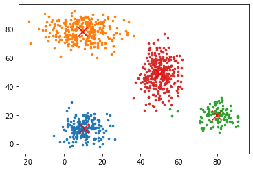

```python
centroids = np.zeros((K, synthetic_data.shape[1]))
centroids[:, 0] = np.random.randint(x_min, x_max, size=K)
centroids[:, 1] = np.random.randint(y_min, y_max, size=K)

centroids = kmeans(synthetic_data, centroids)
silhouette_coefficient = silhouette_score(synthetic_data, centroids)

print('silhouette_coefficient =', silhouette_coefficient)
plot_clusters(synthetic_data, centroids)
```

**Exercise:**

- Run the clustering multiple times and pay attention to the results.
- In the *Discussion* below, describe your observations and discuss reasons for the possibly strong or weak performance of the algorithm. If you identify any weaknesses, suggest a possible solution.

## Discussion

Multiple executions reveal the varying clustering quality. This is due to the randomly initialized centroids and the sensitivity of the k-means algorithm to it. I.e. the cluster quality depends highly on the initial centroids.

## Comments

Our k-means clustering implementation can be characterized as a naive. This is for following reasons:

- We are evaluating only one `k` value instead of trying multiple.
- We are initializing the centroids randomly instead of using some heuristic.
- We are initializing and evaluating only one set of centroids instead of initializing multiple sets and analyzing their SSE (Sum of Squared Errors) or Silhouette Coefficient.

✌️